# LeMaRns

Length-based Multispecies Analysis by Numerical Simulation in R

Michael A. Spence, Hayley J. Bannister, Johnathan E. Ball and Robert B. Thorpe

2019-10-08

# Introduction

LeMans (Length-based Multispecies analysis by numerical simulation) is a length-structured fish community model, with the fish community being represented in terms of both species and length (Hall et al. 2006). By representing many processes, including fishing, natural mortality, and predation as functions of length, it is possible to reproduce many aspects of the community dynamics (including the tendency of diet to change with increasing predator size) with a relatively small number of parameters, and modest requirement for data in model set up. This makes the framework particularly suitable for use in data-limited fisheries.

Most assessment models have a single-species focus, which is appropriate for assessing the current state of the stock and making a very short term forecast, but in the longer-term, stock mortality and abundance will depend on its interactions with other parts of the food-web, and so in general any longer-term projections require the use of a multispecies model.

Assessment models are typically age-structured, i.e. they split the stock(s) being modelled into age classes (e.g. 1 year or 2 year old cod). This is the natural time frame for assimilating annual recruitment into a single-stock, but it is not useful for multispecies interactions, which are typically based upon the relative sizes of predator and prey, rather than being age-dependent. Consequently, LeMans represents stocks in terms of their length. This allows predation to emerge as a function of the relative lengths of predator and prey, and enables the observed shifts in diet as fish grow larger to emerge naturally rather than having to be ignored or hardwired (as for example happens in bulk biomass models such as surplus-production models or indeed Ecopath (Polovina 1984)). Size-structuring can be done either by weight (e.g. mizer; Scott, Blanchard, and Andersen (2014)), or length (e.g. FishSUMS; Speirs et al. (2010)). In LeMans we choose length because a) it is generally easier to measure than weight in the field (Conner, Matson, and Kelly 2017), and b) fisheries selectivity is normally characterised in terms of a relationship with length, which can more easily be related to the structure of fishing nets, and hence it is easier to relate to the parameterisation of mixed fisheries.

Unlike many size-based models, LeMans models predation in terms of a simple type II functional response rather than through the determination of encounter probabilities, and growth is assumed to follow the von Bertalanffy relationship rather than being food-limited, so the model would not be suitable for use in strongly food-limited ecosystems (e.g. the Baltic) unless modified. Where possible, generic relationships with length are applied to the key model processes, and this together with the assumption of von Bertalanffy growth makes the model data requirements relatively modest, facilitating its use in data-limited situations. Another key strength of the model is its ability to accommodate fleet dynamics (due to its length-based structure, simplicity, and speed of execution).

No model structure is perfect, and all involve making some trade-offs between comprehensiveness, run-time, flexibility and transparency, but LeMans is well suited for use whenever there is a need for multispecies or mixed fisheries analysis, but insufficient data to support the use of more complicated model, such as Ecopath or Atlantis (Fulton et al. 2011), provided that growth is not strongly food-limited.

# Setting up the model

## Dataset for the North Sea

In the `LeMaRns` package we supply data for the North Sea model (Thorpe et al. 2015). This includes the species parameters `NS_par` and the interaction matrix `NS_tau`.

```r
NS_par
```

```
#>     species_names   Linf    W_a    W_b     k  Lmat           a
#> 1           Sprat  16.55 0.0059 3.1088 0.681 12.14 885.6667731
#> 2           Npout  23.75 0.0075 3.0244 0.849 17.21 225.0988055
#> 3         Sandeel  23.57 0.0049 2.7826 1.000 12.16 231.6879245
#> 4        Poor cod  23.00 0.0082 3.0865 0.520 15.00 254.2279144
#> 5  Long rough dab  25.00 0.0053 3.1434 0.340 15.00 185.3071561
#> 6             Dab  32.40 0.0159 2.8639 0.536 12.96  69.3184724
#> 7         Herring  33.35 0.0048 3.1984 0.606 23.39  62.1228287
#> 8  Horse mackerel  28.00 0.0316 2.6520 0.380 19.00 120.5695838
#> 9      Lemon sole  37.00 0.0123 2.9713 0.420 27.00  41.8978427
#> 10           Sole  46.41 0.0089 3.0172 0.284 20.96  17.7411663
#> 11       Mackerel  38.00 0.0052 3.1674 0.510 26.00  37.8676686
#> 12        Whiting  52.50 0.0099 2.9433 0.323 21.39  11.1149557
#> 13          Witch  44.00 0.0017 3.3887 0.200 29.00  21.7175060
#> 14        Gurnard  42.97 0.0160 2.8151 0.266 17.67  23.7587503
```

[output cut: 29 more lines]

`NS_par` contains several variables that are required to set up the model: `Linf`, the von-Bertalanffy asymptotic length of each species (cm); `W_a` and `W_b`, length-weight conversion parameters; `k`, the von-Bertalanffy growth parameter; `Lmat` the length at which 50% of the individuals are mature (cm); `a`, the density-independent part of the hockey-stick recruitment function and `b`, the density-dependent part of the hockey-stick recruitment function.

`NS_tau` is the interaction matrix for the species in the model. Each row of the matrix represents a prey species and each column represents a predator species. If element `i,j` is equal to `1` it means that the `j`th species predates on the `i`th species.

`NS_other` is other food for the North Sea.

## Setting the species-independent parameters

The LeMans model is based on a discrete time discrete length system where there are $n_s$ species and $n_l$ length classes with the $l_j$ being the lower length of the $j$th length class and $l_{j+1}$ being the upper limit. The mid point of the $j$th length class is
$$\begin{equation*}
L_j=l_j+\frac{l_{j+1}-l_{j}}{2}
\end{equation*}$$

for $j=1\ldots{}n_l$.

To run LeMans model we must a number of species-independent parameters before it can be run. These parameters include: `nfish`, the number of species in the model; `nsc`, the number of length classes in the model and is set to 32 by default; and `l_bound`, `u_bound` and `mid`, which are the lower, upper and mid-points of the length classes respectively. The values of these parameters can be calculated by running:

```r
nfish <- nrow(NS_par)
nsc <- 32
maxsize <- max(NS_par$Linf)*1.01 # the maximum size is 1% bigger than the largest Linf.
l_bound <- seq(0, maxsize, maxsize/nsc); l_bound <- l_bound[-length(l_bound)]
u_bound <- seq(maxsize/nsc, maxsize, maxsize/nsc)
mid <- l_bound+(u_bound-l_bound)/2
```

`phi_min` is the time step of the model and can either be specified explicitly, with a default of 0.1, or calculated (see `calc_phi` in the next section). The LeMans model also has a numerical precision parameter `eps`, which is set to `1e-05` by default.

## Setting the species-specific parameters

### Size, growth and maturity

In addition to the species-independent parameters described above, the LeMans model also requires a number of species-specific parameters. As a minimum the model requires:

```r
Linf <- NS_par$Linf # the von-Bertalanffy asymptotic length of each species (cm)
W_a <- NS_par$W_a # length-weight conversion parameter
W_b <- NS_par$W_b # length-weight conversion parameter
k <- NS_par$k # the von-Bertalanffy growth parameter
Lmat <- NS_par$Lmat # the length at which 50\% of individuals are mature (cm)
```

The length-weight equation is defined for species $i$ in length class $j$ as
$$\begin{equation*}
W_{j,i}=a_iL_j^{b_i}.
\end{equation*}$$
In `LeMaRns` $a_i$ is represented by `W_a` and $b_i$ is represented by `W_b`. The LeMans model assumes that fish grow continuously throughout their lives, with the length of species $i$ at age $t$ being
$$\begin{equation*}
L_{\infty,i}(1-e^{-k_i(t-t_{0,i})}),
\end{equation*}$$

where $L_{\infty,i}$ is the asymptotic length (cm) of the $i$th species, $k_i$ is the von Bertalanffy growth rate and $t_{0,i}$ is the theoretical age at which the $i$th species would be at length 0. In `LeMaRns` $t_{0,i}$ is not required, $L_{\infty,i}$ is represented by `Linf` and $k_i$ is represented by `k`.

The amount of time $t$ that species $i$ spends in length class $j$ is defined as:
$$\begin{equation}
t_{j,i}=\frac{1}{k_i}\times\log\left(\frac{L_{\infty,i}-l_j}{L_{\infty,i}-l_{j+1}}\right).
\end{equation}$$
Assuming that individuals are evenly distributed across the length class, the proportion of individuals of species $i$ that leave length class $j$ due to growth over time $\delta{}t$ is
$$\begin{equation*}
\phi_{j,i}=\frac{\delta{}t}{t_{j,i}}.
\end{equation*}$$

In `LeMaRns` $\phi_{j,i}$, $\forall{}i,j$, is represented by `phi`. In the example below we set `phi_min` equal to 0.1:

```r
tmp <- calc_phi(k, Linf, nsc, nfish, u_bound, l_bound, calc_phi_min=FALSE, phi_min=0.1)
phi <- tmp$phi
phi_min <- tmp$phi_min
```

The amount that a fish of species $i$ in length class $j$ will grow according to the von Bertalanffy growth curve in a time step, $\delta{}t$, is
$$\begin{equation*}
\delta{}L_{j,i}=(L_{\infty,i} - L_{j,i})(1 - \exp(-k_i\delta{}t)).
\end{equation*}$$
This is then converted into weight increments, $\delta{}W_{j,i}=a_i(\delta{}L_{j,i})^{b_i}$, and then divided by the growth efficiency,
$$\begin{equation*}
G_{j,i}=\left(1-\left(\frac{W_{j,i}}{W_{\infty,i}}
\right)^\pi
\right)\times{}g_0,
\end{equation*}$$
where $W_{\infty,i}$ is the weight of a fish of species $i$ of length $L_{\infty,i}$, $\pi$ is the rate at which the growth efficiency decays and $g_0$ is the growth efficiency of a fish of length zero. The amount of food required for the fish to grow according von Bertalanffy growth curve in a time step is then
$$\begin{equation*}
I_{j,i}=\frac{\delta{}W_{j,i}}{G_{j,i}}.
\end{equation*}$$

This is calculated using the `calc_ration_growthfac` function. This calculates: `ration`, the food required (g) for a fish of average size in each length class to grow according von Bertalanffy growth curve in a time step; `sc_Linf`, the length class at which each species reaches `Linf`; `wgt`, a matrix with dimensions `nsc` and `nfish` representing the weight of each species in each length class; and `g_eff`, a matrix with dimensions `nsc` and `nfish` representing the growth efficiency of each species in each length class.

```r
tmp <- calc_ration_growthfac(k, Linf, nsc, nfish, l_bound, u_bound, mid, W_a, W_b
                             , phi_min)
ration <- tmp$ration
sc_Linf <- tmp$sc_Linf
wgt <- tmp$wgt
g_eff <- tmp$g_eff
```

For species $i$ in length class $j$, the proportion of individuals that are mature is defined as:
$$\begin{equation*}
M_{j,i}=\frac{1}{1+\exp\{-\kappa_i(L_j-L^{(mat)}_i)\}}
\end{equation*}$$

where $L^{(mat)}_i$ is the length at which 50% of individuals are mature and $\kappa_i$ is the rate of change from immaturity to maturity. In `LeMaRns` $L^{(mat)}_i$ is represented by `Lmat` and $\kappa_i$ is represented by `kappa`. In Thorpe et al. (2015), $\kappa_i$ is equal to `10` for all species. The proportion of individuals that are mature may thus be calculated by running:

```r
mature <- calc_mature(Lmat, nfish, mid, kappa=rep(10, nfish), sc_Linf)
```

In the LeMans model, fish may feed on each other and on other food (g), which is referred to in `LeMaRns` as `other`.

```r
other <- NS_other
```

### Recruitment

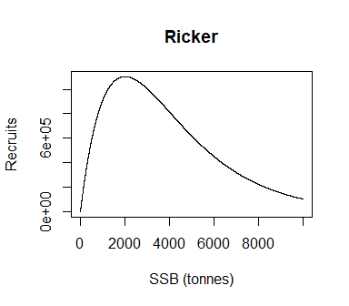

It is also possible to implement the `Beverton-Holt` recruitment function:
$$\begin{equation*}
R_i = \frac{\alpha_iS_i}{1 + \beta_iS_i},
\end{equation*}$$
a `linear` recruitment function:
$$\begin{equation*}
R_i = {\alpha_iS_i},
\end{equation*}$$
a `hockey-stick` recruitment function:
$$\begin{equation*}
R_i = \min({\alpha_iS_i}, R_{max,i})
\end{equation*}$$

where $R_{max,i}$ is the maximum recruitment, or `constant` recruitment $R_i$. Below are examples of these recruitment functions:

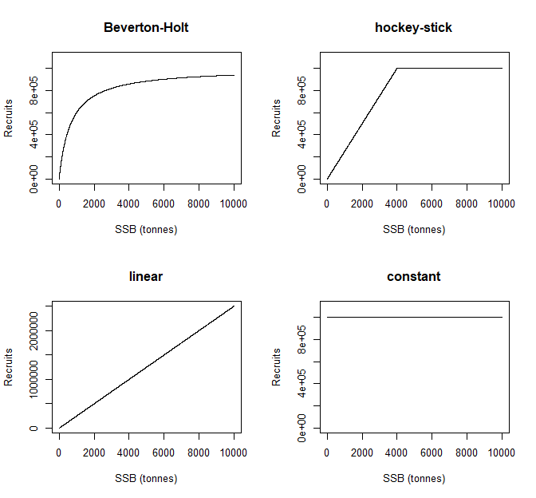

To set up the `hockey-stick` function:

```r
stored_rec_funs <- get_rec_fun(rep("hockey-stick", nfish))
recruit_params <- do.call("Map", c(c, list(a=NS_par$a, b=NS_par$b)))
```

For more details about recruitment see `help(calc_recruits)`.

### Mortality

There are three types of mortality in the LeMans model: background mortality ($M1$), predation mortality ($M2$) and fishing mortality ($F$).

In `LeMaRns`, there are three different options for background mortality functions: `std_RNM`, `constant` and `linear`. `std_RNM` is the default option and gives a constant mortality rate, defined by `Nmort`, for the largest length classes and zero for the smallest. When using the `std_RNM` option, the parameter `prop` is used to define which length classes are considered to have a non-zero mortality rate. `constant` gives a constant mortality rate, defined by `Nmort`, for all length classes and `linear` gives `M1=0` for the first length class, followed by a linear increase in $M1$ up to and including the `sc_Linf`-th length class where `M1=Nmort`.

Below gives examples of the different `M1` functions for a species with an $L_{\infty}$ of 125:

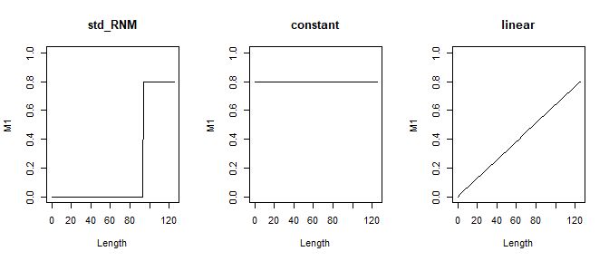

To set up the `std_RNM` natural mortality function with a `prop` of 0.75 and an `Nmort` of 0.8:

```r
M1 <- calc_M1(nsc, sc_Linf, phi_min,
              natmort_opt=rep("std_RNM", length(sc_Linf)),
              Nmort=rep(0.8, length(sc_Linf)),
              prop=rep(0.75, length(sc_Linf)))
```

The species in the model interact with each other via predator-prey interactions. The prey weight preference $w_p$ for a predator of weight $w$ is defined as:
$$\begin{equation*}
p(w, w_p)=\exp\left\{-
\frac{\left(\log_{10}\left(\frac{w_p}{w}\right)-\mu_p\right)^2}{2\sigma_p}
\right\},
\end{equation*}$$

where $\mu_p$ is the preferred predator-prey mass ratio and $\sigma_p$ is the width of the weight preference function. In `LeMaRns` $\mu_p$ is represented by `pred_mu`, $\sigma_p$ is represented by `pred_sigma` and prey weight preferences are calculated by running:

```r
prefs <- calc_prefs(pred_mu=-2.25, pred_sigma=0.5, wgt, sc_Linf)
```

The suitability of prey of weight $w_p$ and species $j$ for a predator of weight $w$ of species $i$ is defined as:
$$\begin{equation*}
U(w,w_p,i,j)=p(w, w_p)\tau_{i,j},
\end{equation*}$$

where $\tau_{i,j}$ is a value between 0 and 1 that represents the vulnerability of prey species $j$ to predator species $i$ (Hall et al. 2006). In `LeMaRns` prey suitability is calculated by running:

```r
suit_M2 <- calc_suit_vect(nsc, nfish, sc_Linf, prefs, NS_tau)
```

This returns a list object of length `nfish`. Each element in the list is an array of dimensions `nsc`, `nsc` and `nfish` containing a value between 0 and 1 that represents a combination of prey preference and prey suitability for each species and length class, which is then used to determine predation mortality.

In the LeMans model, fishing mortality is dependent on effort and gear catchability. The instantaneous fishing mortality for species $i$ of in length class $j$ is
$$\begin{equation*}
F_{j,i} = \sum_{k=1}^{H}e_kq_{i,k}(L_j),
\end{equation*}$$
where $e_k$ is the effort of the $k$th gear, for $k=1\ldots{}H$, and $q_{i,k}(L_j)$ is the catchability of a fish of length $L_j$ and species $i$ by gear $k$. Effort is added to the model during initialisation (see the next section for more details), whilst catchability is added when setting up the model. `LeMaRns` provides three in-built options for catchability curves: `logistic`, `log_gaussian` and `knife-edge`, but it also allows users to input their own catchability values using the `custom` input. The `logistic` curve is defined as:
$$\begin{equation*}
q(L) = \frac{1}{1+\exp(-\eta(L-L_{50}))},
\end{equation*}$$

where $\eta$ is the steepness of the slope of the catchability curve and $L_{50}$ is the length at 50% of the maximum catchability. This function gives a catchability of zero for the smallest length classes, a catchability of 1 for the largest length classes, and a smooth increase in catchability from zero to one around $l_{50}$. An example of a `logistic` catchability curve is shown below with an $\eta$ of 0.25 and an $L_{50}$ of 50:

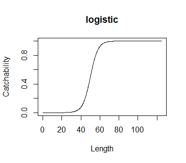

The `log_gaussian` catchability function is defined as:
$$\begin{equation*}
q(L) = \frac{1}{L\sigma\sqrt{2\pi}}\exp\left\{
-\frac{(\log(L)-\log(\mu_{50}))^2+\log(\mu_{50})-\sigma^2}{2\sigma^2}
\right\}
\end{equation*}$$

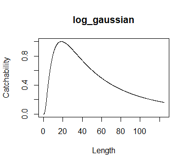

The `knife-edge` function is
$$\begin{equation*}
q(L)=
\begin{cases}
1 & \quad \text{if } L\geq{}L_\mu\\
0 & \quad \text{otherwise,}
\end{cases}
\end{equation*}$$

where $L_\mu$ is the smallest length that is caught by the gear. An example of a `knife-edge` catchability curve is shown below with a $L_\mu$ of 50:

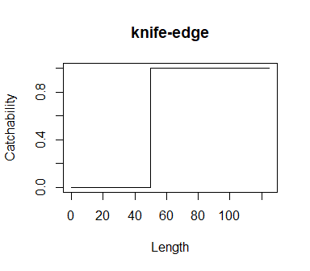

We provide a case study that explores the use of multiple different gears at the end of the vignette, but for now we will set up a gear for each species that follows a `logistic` catchability curve with a $L_{50}$ at `Lmat`. In `LeMaRns` $\eta$ is represented by `eta` and $L_{50}$ is represented by `L50`:

```r
Qs <- calc_Q(nsc=nsc, nfish=nfish, mid=mid, l_bound=l_bound, u_bound=u_bound,
             species_names=NS_par$species_names,curve=rep("logistic", nfish),
             species=NS_par$species_names, max_catchability=rep(1, nfish),
             gear_name=NS_par$species_names,eta=rep(0.25, nfish), L50=Lmat)
```

## `LeMans_param` objects

A `Lemans_param` object can be used to store the model parameters (see `help(Lemans_param)` for further details). It is possible to create a `Lemans_param` object by running:

```r
NS_params <- new("LeMans_param",
                  nsc=nsc,
                  nfish=nfish,
                  phi_min=phi_min,
                  l_bound=l_bound,
                  u_bound=u_bound,
                  mid=mid,
                  species_names=NS_par$species_names,
                  Linf=Linf,
                  W_a=W_a,
                  W_b=W_b,
                  k=k,
                  Lmat=Lmat,
                  mature=mature,
                  sc_Linf=sc_Linf,
                  wgt=wgt,
                  phi=phi,
                  ration=ration,
                  other=other,
                  M1=M1,
                  suit_M2=suit_M2,
                  Qs=Qs,
                  stored_rec_funs=stored_rec_funs,
                  eps=1e-05,
                  recruit_params=recruit_params)
```

Alternatively a `Lemans_param` object can be created using the `LeMansParam` function. This function can be used in several ways. For example, the parameters can be given individually:

```r
NS_params <- LeMansParam(species_names=NS_par$species_names,
                         Linf=Linf, k=k, W_a=W_a, W_b=W_b,
                         Lmat=Lmat, tau=NS_tau,
                         recruit_params=list(a=NS_par$a, b=NS_par$b),
                         eta=rep(0.25, 21), L50=Lmat)
```

the species parameters can be provided as a `data.frame` (referred to as `df`):

```r
NS_params <- LeMansParam(NS_par, tau=NS_tau, eta=rep(0.25, 21), L50=NS_par$Lmat, other=NS_other)
```

and/or the gear types can be provided as a `data.frame` (referred to as `gdf`; see the gear examples below). As a minimum the species data frame must contain `Linf`, `k`, `W_a`, `W_b` and `Lmat`. It is also possible to include `species_names`, `kappa`, `rec_fun`, `natmort_opt`, `Nmort` and `prop`. Any additional variables are assumed to be recruitment parameters and a warning is shown to highlight this, i.e.

```
#> Warning in .local(df, gdf, ...): The following columns of df do not match any of the species arguments and were therefore added to recruit_params:
#> a, b
```

# Running the model

The LeMans model works by projecting the number of individuals in each length class for each species forward in time. `N` is therefore a `nsc` by `nfish` matrix where `N[j,i]` is the number of individuals of species `i` that are in length class `j`. We will refer to $N_{j,i,t}$ as the number of individuals of species $i$ in length class $j$ and time $t$.

## Initialising the model

Given all of the aforementioned parameters, the minimum requirement for the model to be run is an initial matrix `N`. `N` can be calculated using an `intercept` of e.g. 1e10 and a `slope` of e.g. -5 by running:

```r
N <- get_N0(nsc, nfish, mid, wgt, sc_Linf, intercept=1e10, slope=-5)
```

In this function the total number of individuals in the community in each length class is equal to `intercept*mid^slope`. Within each length class, the number of individuals of each species is determined using the proportion of each species’ biomass that is found in that length class. We can now plot the initial size spectrum of the model:

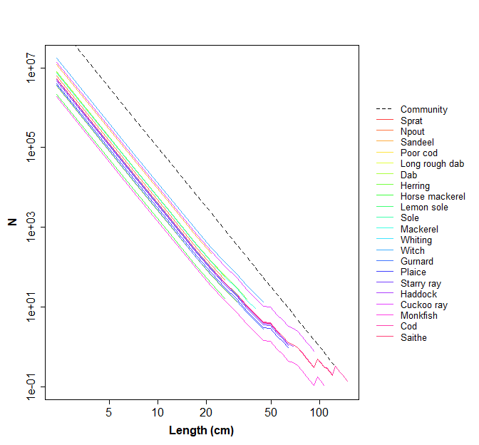

The fishing mortality, `Fs`, must also be defined. To do this we need to define the `effort` for each of the gears `Qs`. In this example we will set the effort to be 0.5 for all species:

```r
effort <- rep(0.5, dim(Qs)[3])
Fs <- matrix(0, nsc, nfish)
for (j in 1:length(effort)) {
   Fs <- Fs+effort[j]*Qs[,,j]
}
```